# Bernie Sanders & Donald J. Trump Contributions.

Kris Anaya

5/22/2017

This report explores a dataset containing canidates and attributes for approximately 490,000 contributions.

# Univariate Plot Section

```
## 'data.frame':    493422 obs. of  12 variables:
##  $ name      : Factor w/ 107161 levels "& DREW BURKE, MELANIE",..: 1 2 3 3 3 4 5 5 5 5 ...
##  $ canidate  : Factor w/ 3 levels "cand_nm","Sanders, Bernard",..: 2 2 2 2 2 2 2 2 2 2 ...
##  $ city      : Factor w/ 2251 levels "29 PALMS","ACAMPO",..: 1067 807 681 681 681 956 225 225 225 225 ...
##  $ state     : Factor w/ 2 levels "CA","contbr_st": 1 1 1 1 1 1 1 1 1 1 ...
##  $ zip       : num  9.55e+08 9.25e+08 9.29e+08 9.29e+08 9.29e+08 ...
##  $ employer  : Factor w/ 29481 levels "","-","- NONE -",..: 12217 10319 13216 13216 13216 3465 10227 10227 10227 10227 ...
##  $ occupation: Factor w/ 13683 levels "","-","----",..: 6653 6653 7000 7000 7000 8062 5233 5233 5233 5233 ...
##  $ amount    : num  50 244 15 50 50 ...
##  $ date      : POSIXlt, format: "2016-04-17" "2015-09-04" ...
##  $ receipt   : Factor w/ 37 levels "","* EARMARKED CONTRIBUTION: SEE BELOW REATTRIBUTION/REFUND PENDING",..: 1 1 1 1 1 1 1 1 1 1 ...
##  $ lon       : num  -123 -117 -118 -118 -118 ...
##  $ lat       : num  39.4 34 33.8 33.8 33.8 ...
```

```
##                  name                    canidate
##  WEIL, MONIQUE     :   257   cand_nm         :     0
##  MCLENNAN, MARLYN  :   240   Sanders, Bernard:407164
##  AUSLENDER, LEONARD:   239   Trump, Donald J.: 86258
##  ISERI, MARTIN     :   220
##  SPEAR, JOSEPH     :   210
##  DAVIDSON, LISA    :   203
##  (Other)           :492053
##             city              state             zip
##  LOS ANGELES  : 33799   CA       :493422   Min.   :        0
##  SAN FRANCISCO: 32011   contbr_st:     0   1st Qu.:900683036
##  SAN DIEGO    : 17770                      Median :926777949
##  OAKLAND      : 13124                      Mean   :759234179
##  SAN JOSE     : 11642                      3rd Qu.:946091302
##  BERKELEY     : 10707                      Max.   :961628693
##  (Other)      :374369
##           employer                      occupation         amount
##  NONE         : 80793   NOT EMPLOYED         :105838   Min.   :-10500.00
##  NOT EMPLOYED : 43044   RETIRED              : 50674   1st Qu.:    15.00
##  RETIRED      : 37507   INFORMATION REQUESTED: 16746   Median :    27.00
##  SELF         : 33131   TEACHER              : 11655   Mean   :    68.16
##  SELF EMPLOYED: 29749   ENGINEER             :  8584   3rd Qu.:    50.00
##  (Other)      :268832   (Other)              :299849   Max.   : 10000.00
##  NA's         :   366   NA's                 :    76
##       date
##  Min.   :2015-05-04 00:00:00
##  1st Qu.:2016-02-27 00:00:00
##  Median :2016-04-06 00:00:00
##  Mean   :2016-04-09 14:49:04
##  3rd Qu.:2016-05-31 00:00:00
##  Max.   :2016-12-31 00:00:00
##
##                                                              receipt
##                                                                  :489797
##  Refund                                                          :  3137
##  * EARMARKED CONTRIBUTION: SEE BELOW REATTRIBUTION/REFUND PENDING:   431
##  REATTRIBUTION/REFUND PENDING                                    :    16
##  REATTRIBUTION TO SPOUSE, TERRIE SCHULTZ.                        :     4
##  REATTRIBUTION FROM SPOUSE, DEDE WHITESIDE.                      :     3
##  (Other)                                                         :    34
##       lon                lat
##  Min.   :-124.286   Min.   :23.15
##  1st Qu.:-122.236   1st Qu.:34.05
##  Median :-120.572   Median :36.68
##  Mean   :-120.112   Mean   :36.00
##  3rd Qu.:-118.235   3rd Qu.:37.80
##  Max.   :   2.239   Max.   :48.88
##  NA's   :2727       NA's   :2727
```

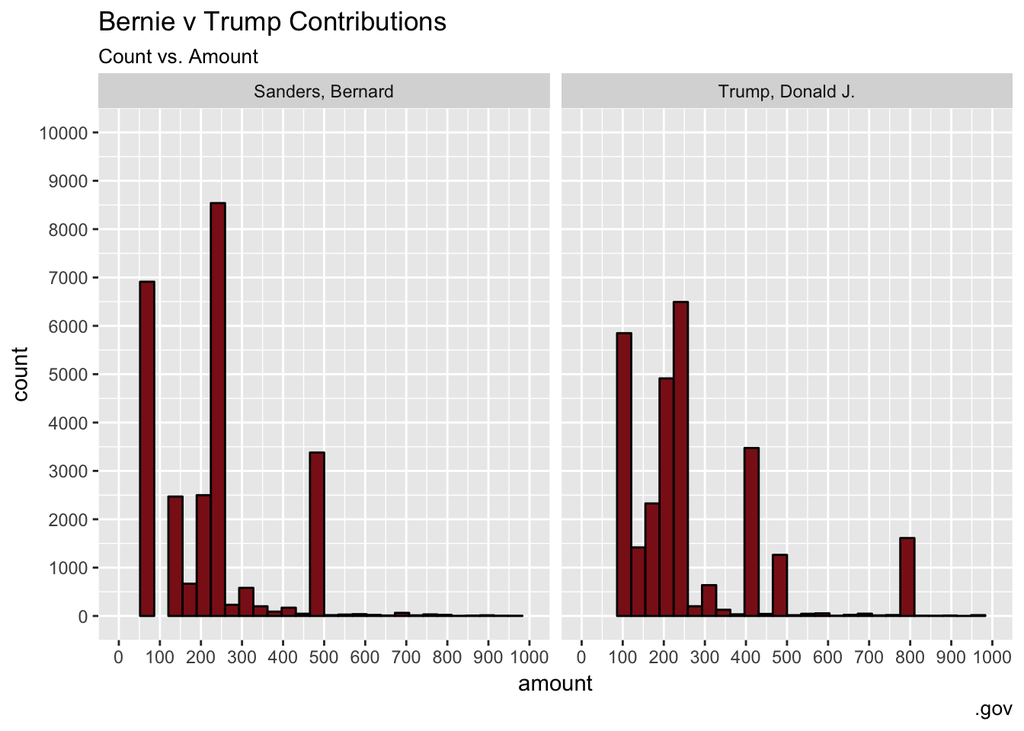

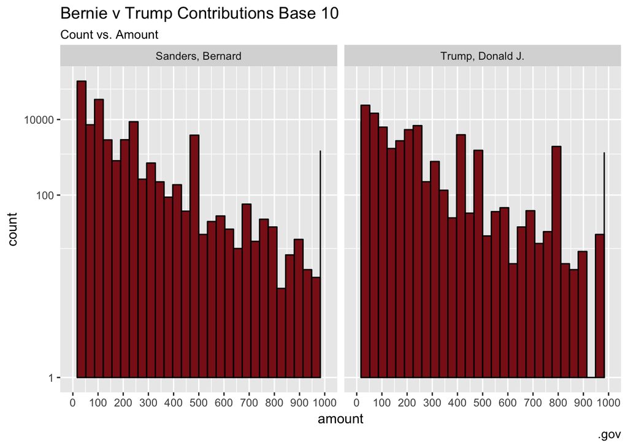

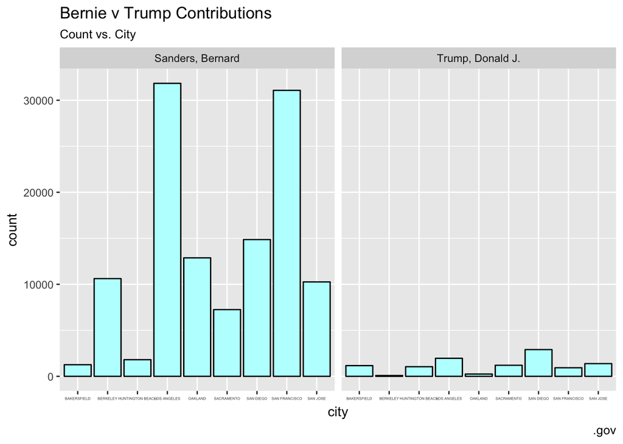

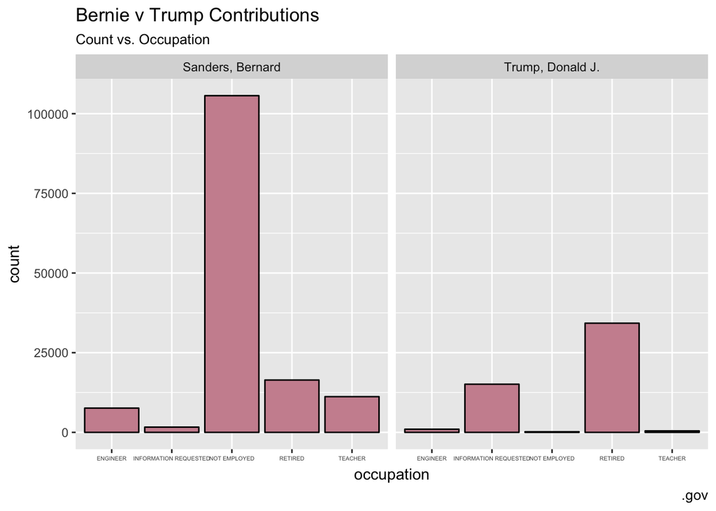

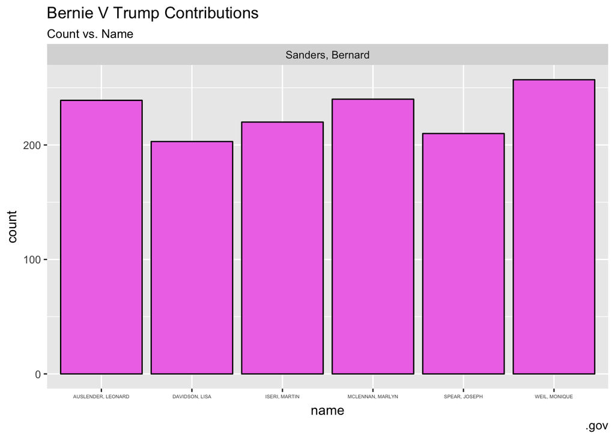

Most Major cities contributed to Bernie’s campaign, with pretty smiliary contributions in Bakersfield and Hunnigton Beach. A majority of occuptations that contributed to Bernie’s campaign are “Not Employed”, while more in Trump’s contributions are “RETIRED”. Finally, that contributed more then two hundred contributions seem to support the Bernied campaign rather than Trump’s. It looks like no large multiple contributions were made with the Trump campaign in California.

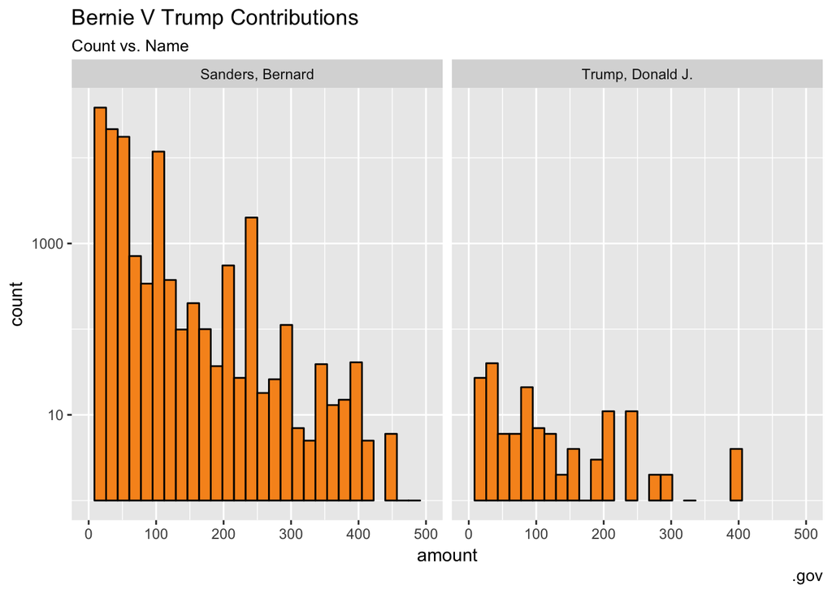

```
## not_employed_df$state: CA
##     Min.  1st Qu.   Median     Mean  3rd Qu.     Max.
## -2300.00    15.00    27.00    50.16    50.00  5000.00
## --------------------------------------------------------
## not_employed_df$state: contbr_st
## NULL
```

If we consider the unemployment between two canidates it would seem that mister Sanders has the largest. Most poeple who are unemployed fall into the zero to hundred dollar amount while we see a converging pattern as the amount increases. Within the summary we see that the median is exactly twenty-seven dollars the same amount which Mr. Sanders proclaimed in his campaign speeches.

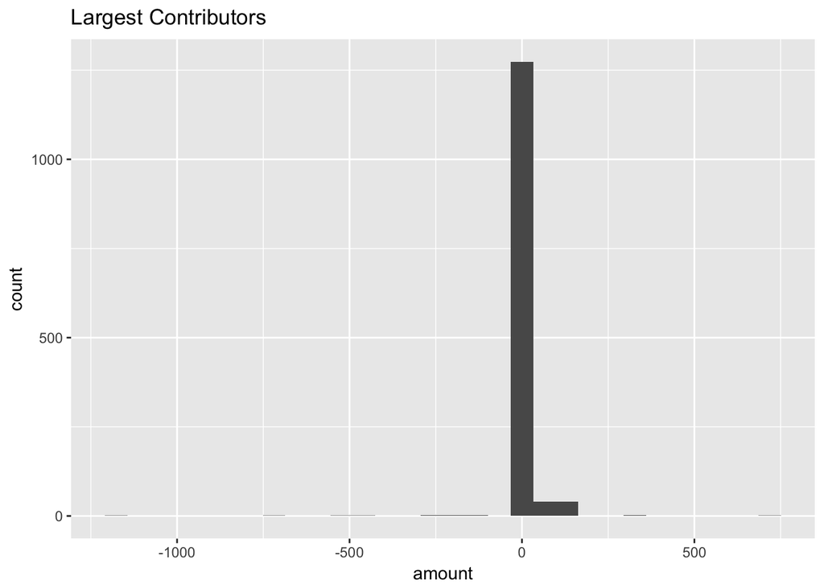

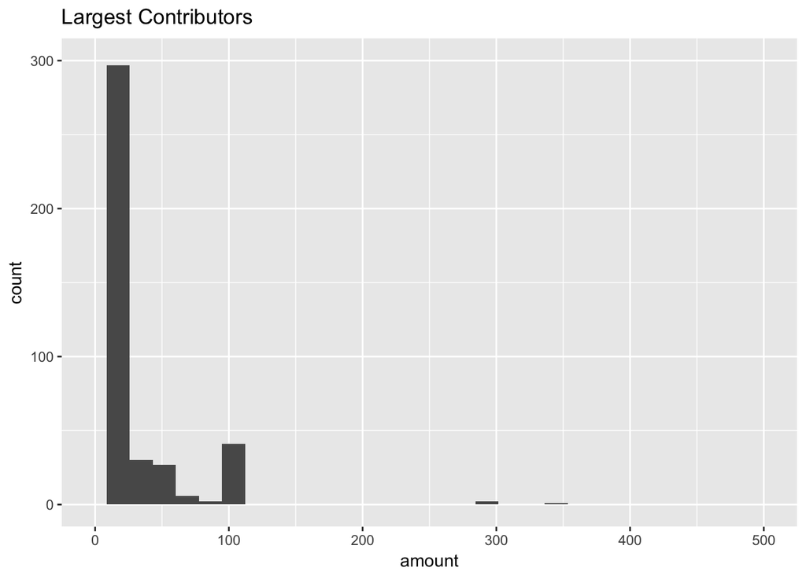

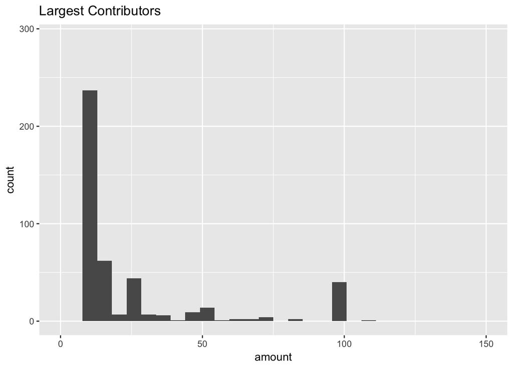

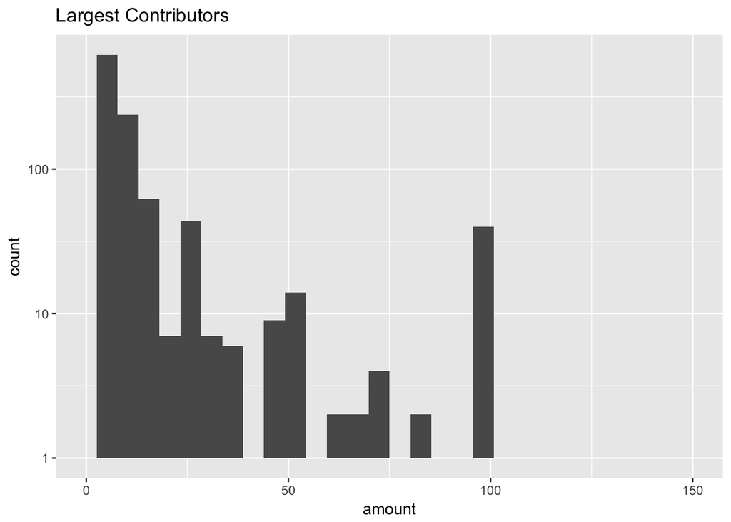

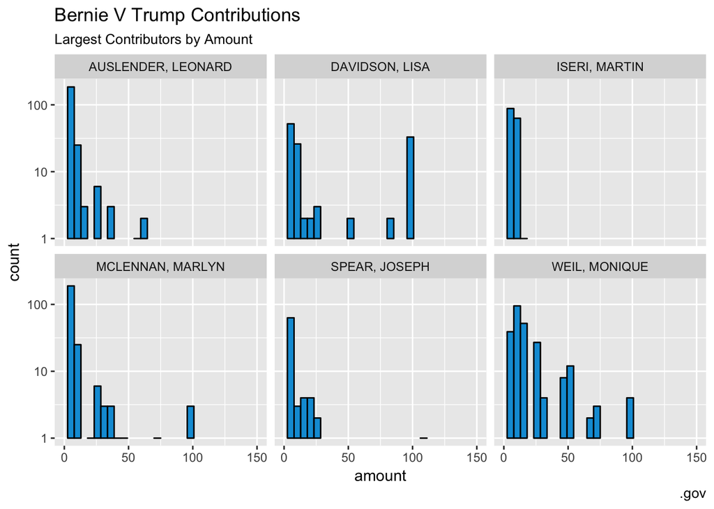

I wanted to do a step by step approach of the dataset of the names who contributed the most. All of these names contributed to the Bernie Sanders campaign as was visualized above. When we zoom in and look closer at the data and seperate the names in each column while taking a log transformation of the slightly skewed chart we can get a very clear visualization of how the contributors spread out there payments. I didn’t want to get into the refund payments just yet in the data set because it requires multiple variables to investigate further, but as you can see from the chart above most of the contributions to the Sanders Campaign were paid around a wide variety of ranges.

```
## 'data.frame':    493422 obs. of  12 variables:
##  $ name      : Factor w/ 107161 levels "& DREW BURKE, MELANIE",..: 1 2 3 3 3 4 5 5 5 5 ...
##  $ canidate  : Factor w/ 3 levels "cand_nm","Sanders, Bernard",..: 2 2 2 2 2 2 2 2 2 2 ...
##  $ city      : Factor w/ 2251 levels "29 PALMS","ACAMPO",..: 1067 807 681 681 681 956 225 225 225 225 ...
##  $ state     : Factor w/ 2 levels "CA","contbr_st": 1 1 1 1 1 1 1 1 1 1 ...
##  $ zip       : num  9.55e+08 9.25e+08 9.29e+08 9.29e+08 9.29e+08 ...
##  $ employer  : Factor w/ 29481 levels "","-","- NONE -",..: 12217 10319 13216 13216 13216 3465 10227 10227 10227 10227 ...
##  $ occupation: Factor w/ 13683 levels "","-","----",..: 6653 6653 7000 7000 7000 8062 5233 5233 5233 5233 ...
##  $ amount    : num  50 244 15 50 50 ...
##  $ date      : POSIXlt, format: "2016-04-17" "2015-09-04" ...
##  $ receipt   : Factor w/ 37 levels "","* EARMARKED CONTRIBUTION: SEE BELOW REATTRIBUTION/REFUND PENDING",..: 1 1 1 1 1 1 1 1 1 1 ...
##  $ lon       : num  -123 -117 -118 -118 -118 ...
##  $ lat       : num  39.4 34 33.8 33.8 33.8 ...
```

```
##                  name                    canidate
##  WEIL, MONIQUE     :   257   cand_nm         :     0
##  MCLENNAN, MARLYN  :   240   Sanders, Bernard:407164
##  AUSLENDER, LEONARD:   239   Trump, Donald J.: 86258
##  ISERI, MARTIN     :   220
##  SPEAR, JOSEPH     :   210
##  DAVIDSON, LISA    :   203
##  (Other)           :492053
##             city              state             zip
##  LOS ANGELES  : 33799   CA       :493422   Min.   :        0
##  SAN FRANCISCO: 32011   contbr_st:     0   1st Qu.:900683036
##  SAN DIEGO    : 17770                      Median :926777949
##  OAKLAND      : 13124                      Mean   :759234179
##  SAN JOSE     : 11642                      3rd Qu.:946091302
##  BERKELEY     : 10707                      Max.   :961628693
##  (Other)      :374369
##           employer                      occupation         amount
##  NONE         : 80793   NOT EMPLOYED         :105838   Min.   :-10500.00
##  NOT EMPLOYED : 43044   RETIRED              : 50674   1st Qu.:    15.00
##  RETIRED      : 37507   INFORMATION REQUESTED: 16746   Median :    27.00
##  SELF         : 33131   TEACHER              : 11655   Mean   :    68.16
##  SELF EMPLOYED: 29749   ENGINEER             :  8584   3rd Qu.:    50.00
##  (Other)      :268832   (Other)              :299849   Max.   : 10000.00
##  NA's         :   366   NA's                 :    76
##       date
##  Min.   :2015-05-04 00:00:00
##  1st Qu.:2016-02-27 00:00:00
##  Median :2016-04-06 00:00:00
##  Mean   :2016-04-09 14:49:04
##  3rd Qu.:2016-05-31 00:00:00
##  Max.   :2016-12-31 00:00:00
##
##                                                              receipt
##                                                                  :489797
##  Refund                                                          :  3137
##  * EARMARKED CONTRIBUTION: SEE BELOW REATTRIBUTION/REFUND PENDING:   431
##  REATTRIBUTION/REFUND PENDING                                    :    16
##  REATTRIBUTION TO SPOUSE, TERRIE SCHULTZ.                        :     4
##  REATTRIBUTION FROM SPOUSE, DEDE WHITESIDE.                      :     3
##  (Other)                                                         :    34
##       lon                lat
##  Min.   :-124.286   Min.   :23.15
##  1st Qu.:-122.236   1st Qu.:34.05
##  Median :-120.572   Median :36.68
##  Mean   :-120.112   Mean   :36.00
##  3rd Qu.:-118.235   3rd Qu.:37.80
##  Max.   :   2.239   Max.   :48.88
##  NA's   :2727       NA's   :2727
```

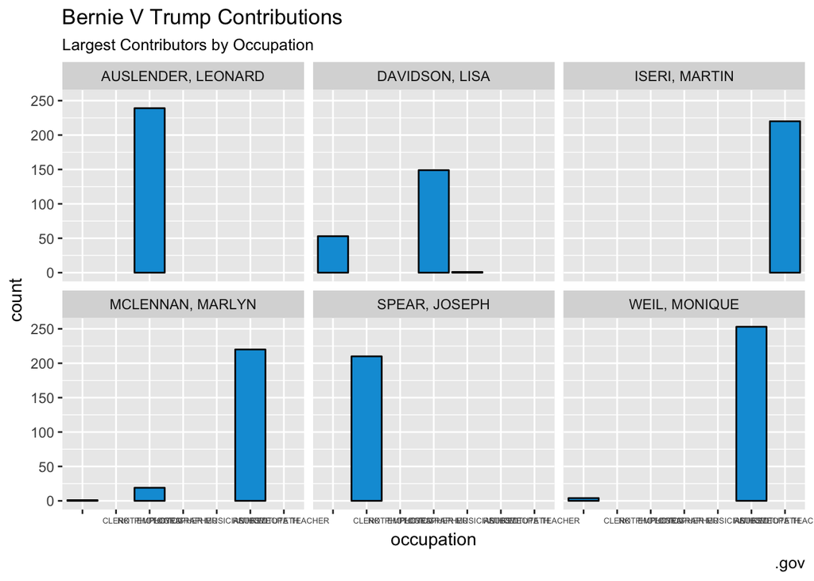

```
##     Min.  1st Qu.   Median     Mean  3rd Qu.     Max.
## -1153.00     2.70     3.00     8.03    10.00   742.40
```

In this second graph concerning occupation you can see that people had standard employments such as Teacher, Not Employed, Retired, Clerk and Photographer. What striked me odd in this barplot was some people changed there occupation with donations for example MCLENNAN, MARLYN was listed as RETIRED and NOT EMPLOYED.

# Univariate Analysis

## What is the structure of your dataset?

This report explores a dataset containing canidates and attributes for approximately 490,000 contributions with 12 features (name,canidate,city,state,zip,employer,occupation,amount,date,receipt,lon,lat). The variables name, canidate, city state, employer, occupation are factors.

Other observations: * cities with most contributors are leaning liberal * largest contributor occupation is not employed * largest count of contributions are Bernie supporters * largest refund is more then alloted 10k * biggest contributions is the upperbound of 10k

## What is/are the main feature(s) of interest in your dataset?

the main features of the dataset are amount, city and occupation. I’d like to determine which features are voting for each respected canidates the most and what is their median or max contributions for each canidate as well as top locations.

## Did you create any new variables from existing variables in the dataset?

They only feature I truly changed within the data set is the datetime which I re translated it to a more formal method so I may view it during my bivariate plot section. Other then that most variables were just re written to express a more readable form.

## Of the features you investigated, were there any unusual distributions? Did you perform

any operations on the data to tidy, adjust, or change the form of the data? If so, why did you do this?

I log-transformed the right skewed of the amount and count of the contributions in the canidate. While the price still has a similar skewedness I wanted to to investigate a deeper understand of the dataset for which it gave me a clear picture and understand of how the data set functioned. Primarly, we can see within the amount that the Sander’s group tends to contribute more in the below hundred dollar range while Trump’s group tends to follow a higher contribution pattern. Most of the distrobutions had okay patterns. They only real unusual visualization I saw was employment being change by person in the largest contributions by occupation graph.

# Bivariate Plots Sections

```
##       date                         amount
##  Min.   :2015-05-04 00:00:00   Min.   :-10500.00
##  1st Qu.:2016-02-27 00:00:00   1st Qu.:    15.00
##  Median :2016-04-06 00:00:00   Median :    27.00
##  Mean   :2016-04-09 14:49:04   Mean   :    68.16
##  3rd Qu.:2016-05-31 00:00:00   3rd Qu.:    50.00
##  Max.   :2016-12-31 00:00:00   Max.   : 10000.00
##              canidate
##  Sanders, Bernard:407164
##  Trump, Donald J.: 86258
##
##
##
##
```

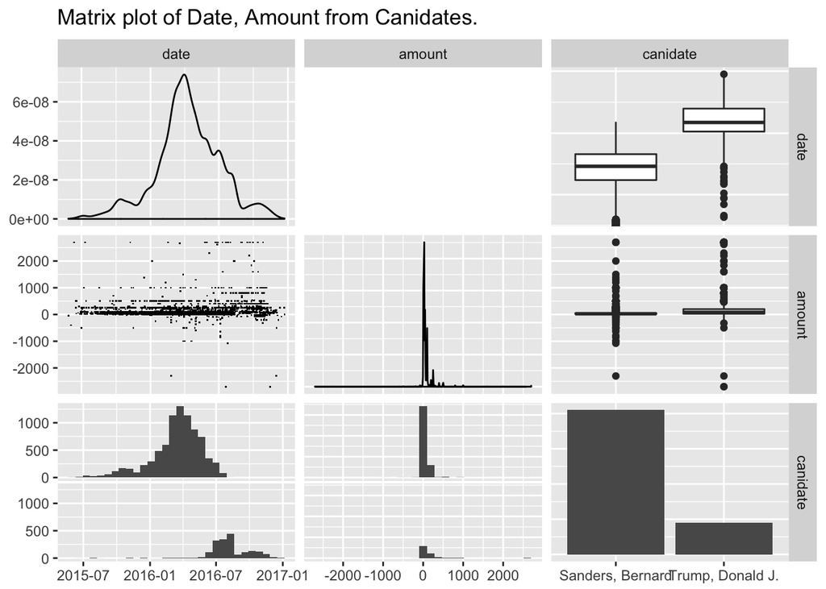

I created a subset of the data with amount, canidate and date. The problem I have in this datset is you don’t have real numerical analysis but primarly location and amount contributions. But, you still can see interesting results in this matrix plot for instance, the canidates by date you see some noramility in one of the canidates. Secondly, if you look at the date time between Jan and July you see a large growth in contributions, let’s investigate this further.

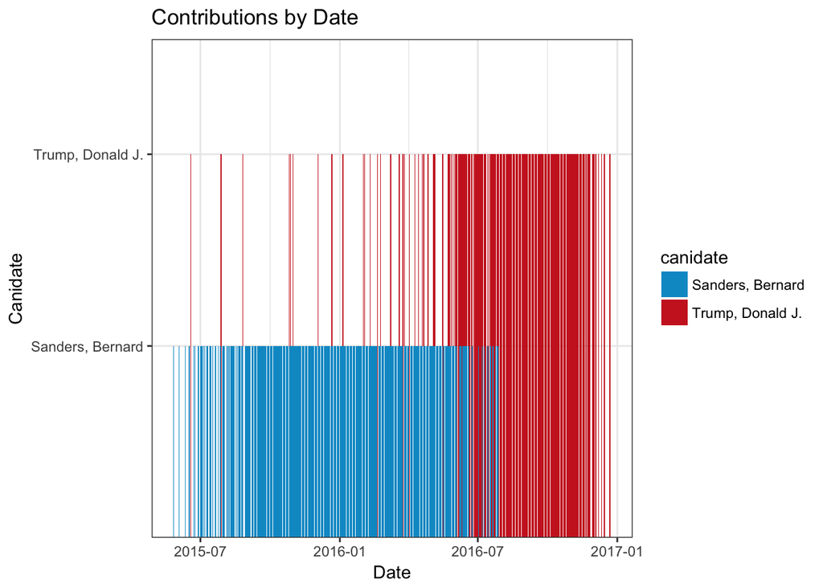

As the date moves into the election you see that donald Trump contributions are growning and Bernies are decreasing. This is due to the fact that Donald Trump went on to become the Repulican party canidate and Bernie Sanders had to drop out of the race. Let’s look at this in a more normal distrubtion.

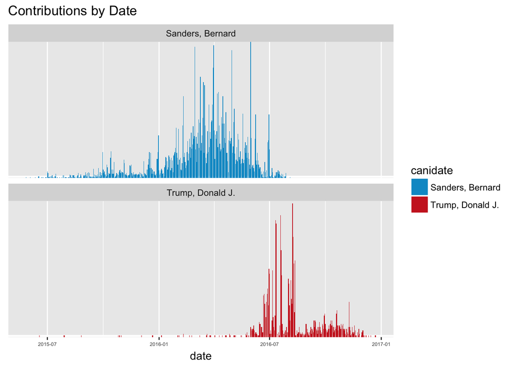

```
## merge_samp$canidate: Sanders, Bernard
##                  Min.               1st Qu.                Median
## "2015-05-27 00:00:00" "2016-02-13 00:00:00" "2016-03-25 00:00:00"
##                  Mean               3rd Qu.                  Max.
## "2016-03-14 15:50:05" "2016-04-30 00:00:00" "2016-08-04 00:00:00"
## --------------------------------------------------------
## merge_samp$canidate: Trump, Donald J.
##                  Min.               1st Qu.                Median
## "2015-06-18 00:00:00" "2016-07-06 00:00:00" "2016-08-02 00:00:00"
##                  Mean               3rd Qu.                  Max.
## "2016-08-07 09:56:08" "2016-09-12 00:00:00" "2016-12-23 00:00:00"
```

Clearly we see that Sanders’ campaign is increasing as the months go on peacking around the third or forth month of 2016. We don’t see large contributions in Donald Trump until the June mark. This could be due to teh fact that he was nominated aroudn this time or it’s possible that California was still not interested in Donald Trump being the Republican canidate and still was hoping for a more moderate conservative like Jeb Bush or John Kasich. These plots do paint a very well detailed portrait of the canidates time running for president.

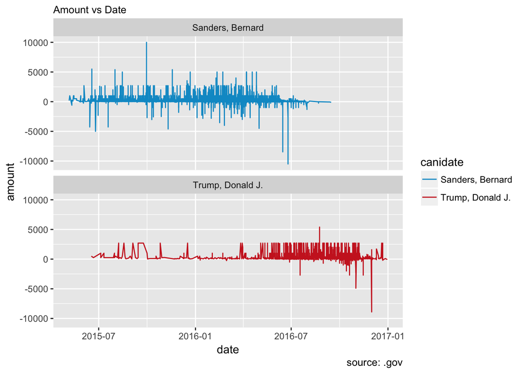

As you may view from above the trend of the line graph by date between Sanders and Trump. Some observations to view are Sander’s data set is not a consistent as Trump’s. Meaning, his data set tends to peak and fall between high donations and refunds, while Trump’s data set seems to look more uniform in nature. Could this have something to do with anixety in the election cylce? One observation to be noted is the negative amount in the y axis. Let’s dive into this a bit closer.

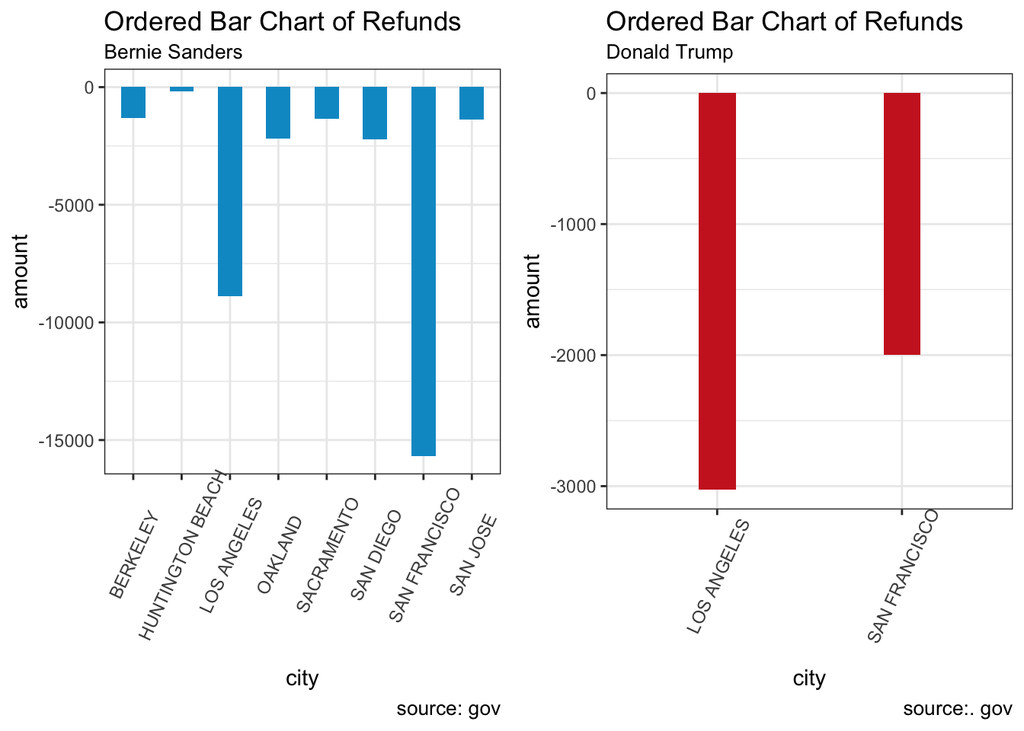

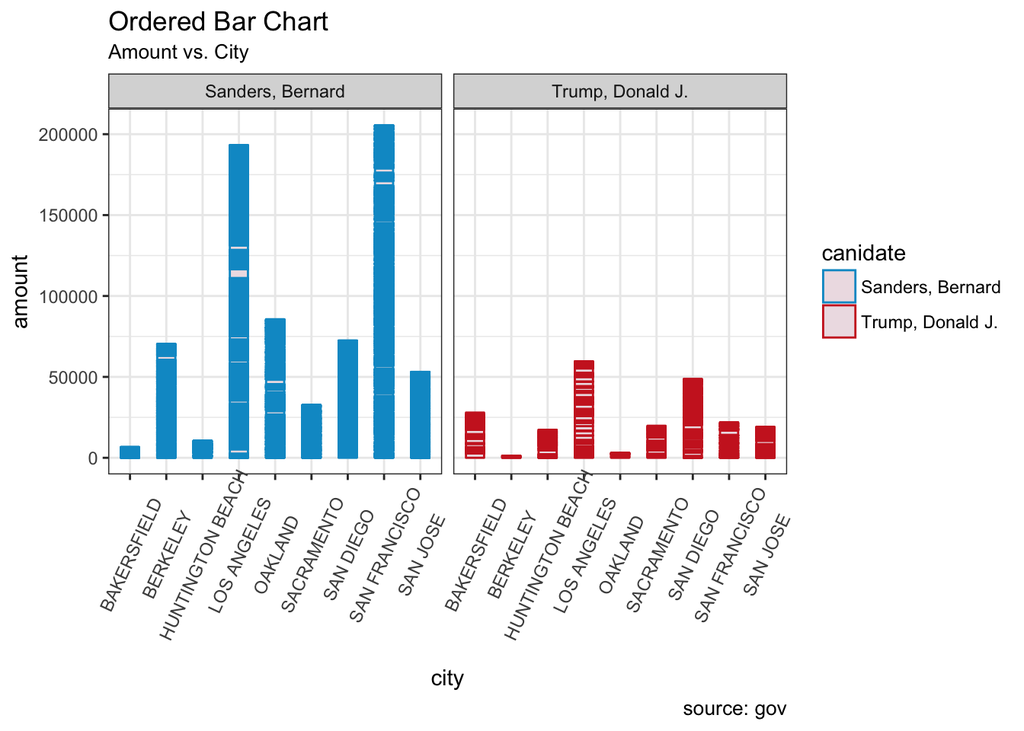

as you can see above most of the refund that were return were by Bernie Sanders campaigne. While some refunds were made by Donald Trump it seems that Bernie Sanders had the most. However, one thing to keep in mind is that Bernie’s dataset is larger so it could account for just more datapoints in the plot. if we look at amounts we can see that Bernie sanders has more contributions in the postive direction as well. Let’s look at these in more depth statistically.

```
## bernie_city$city: BERKELEY
##    Min. 1st Qu.  Median    Mean 3rd Qu.    Max.
## -300.00 -169.50 -100.00 -119.80  -75.00   -5.27
## --------------------------------------------------------
## bernie_city$city: HUNTINGTON BEACH
##    Min. 1st Qu.  Median    Mean 3rd Qu.    Max.
## -100.00  -75.00  -50.00  -58.33  -37.50  -25.00
## --------------------------------------------------------
## bernie_city$city: LOS ANGELES
##    Min. 1st Qu.  Median    Mean 3rd Qu.    Max.
## -2280.0  -362.4  -214.0  -329.1   -71.0   -10.0
## --------------------------------------------------------
## bernie_city$city: OAKLAND
##     Min.  1st Qu.   Median     Mean  3rd Qu.     Max.
## -1000.00  -294.60   -39.59  -244.00   -35.00    -5.00
## --------------------------------------------------------
## bernie_city$city: SACRAMENTO
##    Min. 1st Qu.  Median    Mean 3rd Qu.    Max.
## -500.00 -410.00 -137.50 -222.90  -71.25  -12.50
## --------------------------------------------------------
## bernie_city$city: SAN DIEGO
##    Min. 1st Qu.  Median    Mean 3rd Qu.    Max.
## -500.00 -200.00 -100.00 -158.70  -38.75  -17.50
## --------------------------------------------------------
## bernie_city$city: SAN FRANCISCO
##    Min. 1st Qu.  Median    Mean 3rd Qu.    Max.
## -2700.0  -757.8  -500.0  -653.2  -142.2    -5.0
## --------------------------------------------------------
## bernie_city$city: SAN JOSE
##    Min. 1st Qu.  Median    Mean 3rd Qu.    Max.
## -500.00 -236.20 -123.00 -171.80  -33.36  -20.23
```

```
## trump_city$city: LOS ANGELES
##    Min. 1st Qu.  Median    Mean 3rd Qu.    Max.
##   -3027   -3027   -3027   -3027   -3027   -3027
## --------------------------------------------------------
## trump_city$city: SAN FRANCISCO
##    Min. 1st Qu.  Median    Mean 3rd Qu.    Max.
##   -2000   -2000   -2000   -2000   -2000   -2000
```

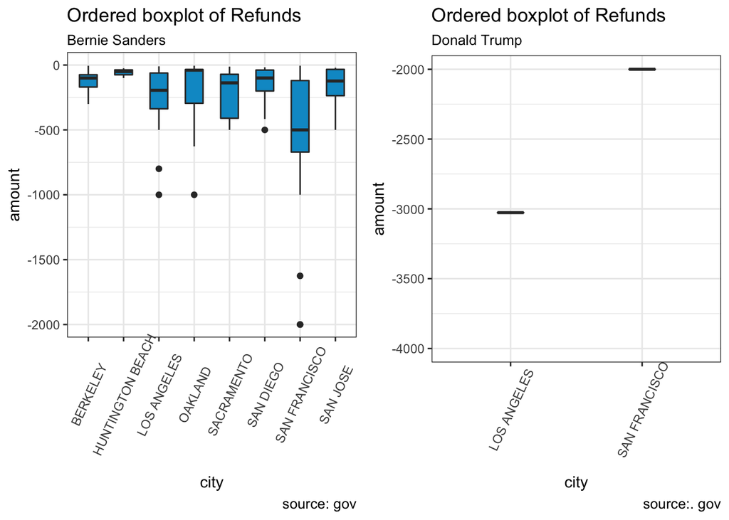

```
## largest_amount_bernie_trump$city: BAKERSFIELD
##    Min. 1st Qu.  Median    Mean 3rd Qu.    Max.
##     1.0    20.0    37.5   130.0   100.0  2700.0
## --------------------------------------------------------
## largest_amount_bernie_trump$city: BERKELEY
##    Min. 1st Qu.  Median    Mean 3rd Qu.    Max.
##    1.00   15.00   27.00   60.17   50.00 2600.00
## --------------------------------------------------------
## largest_amount_bernie_trump$city: HUNTINGTON BEACH
##    Min. 1st Qu.  Median    Mean 3rd Qu.    Max.
##     1.0    15.0    35.0    89.9   100.0  2400.0
## --------------------------------------------------------
## largest_amount_bernie_trump$city: LOS ANGELES
##    Min. 1st Qu.  Median    Mean 3rd Qu.    Max.
##    0.80   15.00   27.00   67.72   50.00 5400.00
## --------------------------------------------------------
## largest_amount_bernie_trump$city: OAKLAND
##    Min. 1st Qu.  Median    Mean 3rd Qu.    Max.
##    1.00   15.00   27.00   61.11   50.00 2700.00
## --------------------------------------------------------
## largest_amount_bernie_trump$city: SACRAMENTO
##    Min. 1st Qu.  Median    Mean 3rd Qu.    Max.
##    1.00   15.00   27.00   58.78   50.00 2000.00
## --------------------------------------------------------
## largest_amount_bernie_trump$city: SAN DIEGO
##    Min. 1st Qu.  Median    Mean 3rd Qu.    Max.
##    1.00   15.00   27.00   61.76   50.00 2700.00
## --------------------------------------------------------
## largest_amount_bernie_trump$city: SAN FRANCISCO
##    Min. 1st Qu.  Median    Mean 3rd Qu.    Max.
##    1.00   15.00   27.00   64.55   50.00 2700.00
## --------------------------------------------------------
## largest_amount_bernie_trump$city: SAN JOSE
##    Min. 1st Qu.  Median    Mean 3rd Qu.    Max.
##    1.00   15.00   27.00   55.96   50.00 2000.00
```

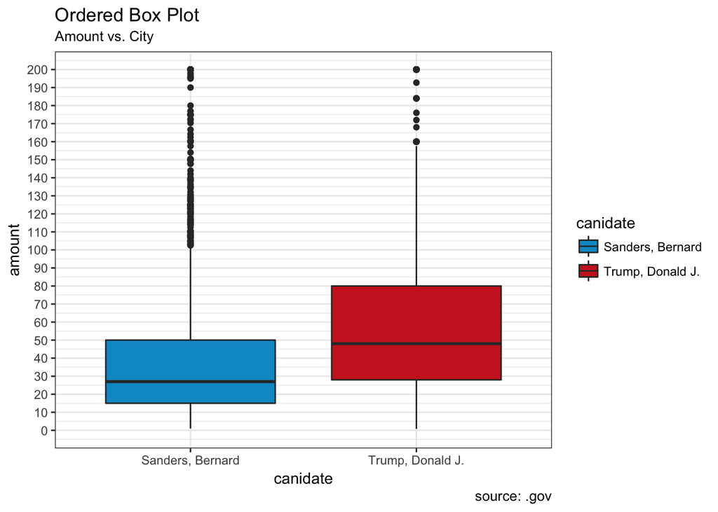

```
##
##  Pearson's product-moment correlation
##
## data:  merge_bs_dt_df$zip and merge_bs_dt_df$amount
## t = -150.4, df = 493420, p-value < 2.2e-16
## alternative hypothesis: true correlation is not equal to 0
## 95 percent confidence interval:
##  -0.2120382 -0.2067023
## sample estimates:
##        cor
## -0.2093718
```

# Bivariate Analysis

## Talk aboust some of the relationships you oberseved in this part of the investiations.

How did the features of interest vary with other features in the dataset.

## Did you obesrve any interesting relationships between teh other features?

There isn’t really any true relationship across the board in this dataset it really just outlines that the Sanders campaign had many contributors who seemed to be up and down along the campaign while Trump’s supports were steady and consistent.

## What is the strongest data point you found?

the strongerst thing I found was Bernie Sanders footnote of twenty-seven dollars. I though that was pretty wonderful.

# Multivariate Plots Section and Final Plots

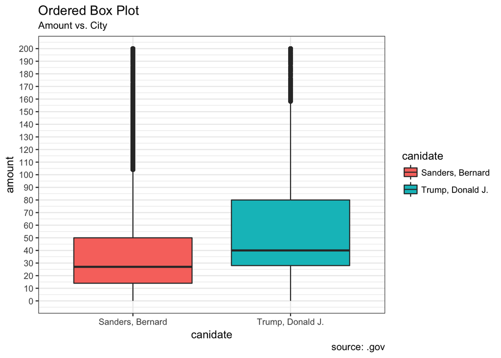

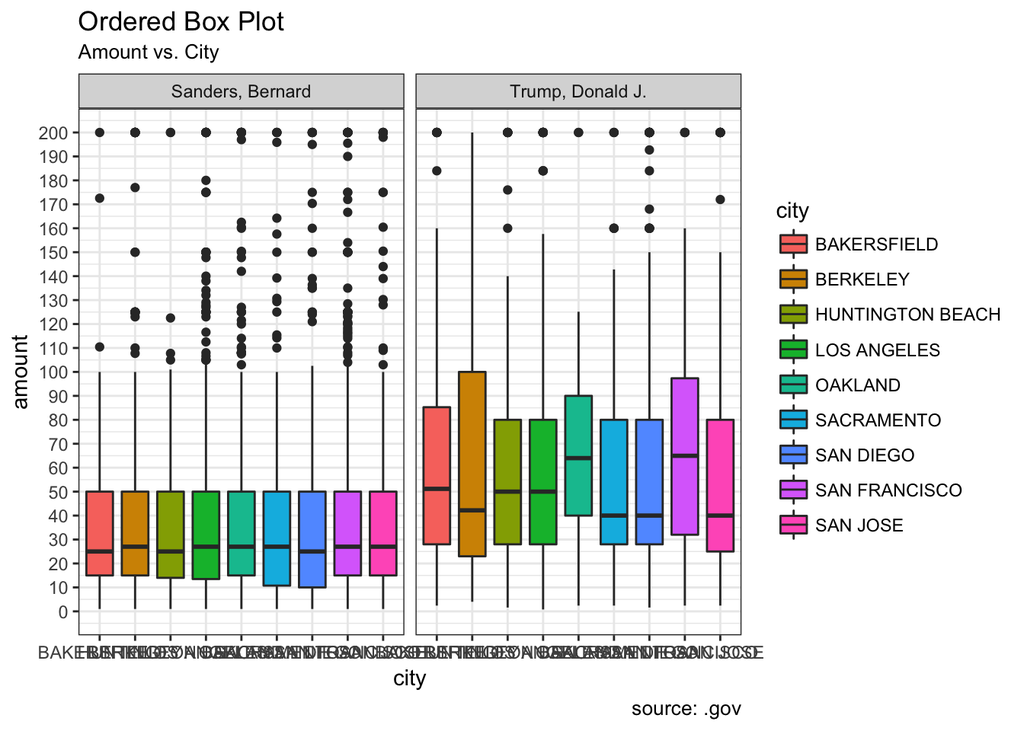

```
##           long      lat group order     region subregion
## 6965 -121.4785 37.48290   157  6965 california   alameda
## 6966 -121.5129 37.48290   157  6966 california   alameda
## 6967 -121.8853 37.48290   157  6967 california   alameda
## 6968 -121.8968 37.46571   157  6968 california   alameda
## 6969 -121.9254 37.45998   157  6969 california   alameda
## 6970 -121.9483 37.47717   157  6970 california   alameda
```

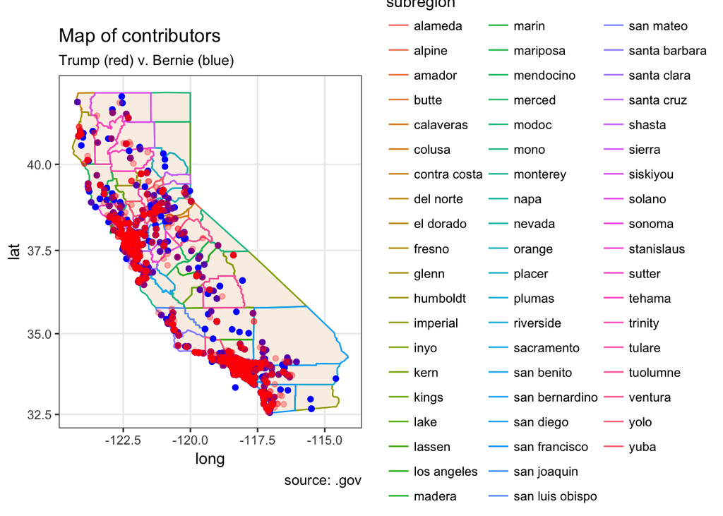

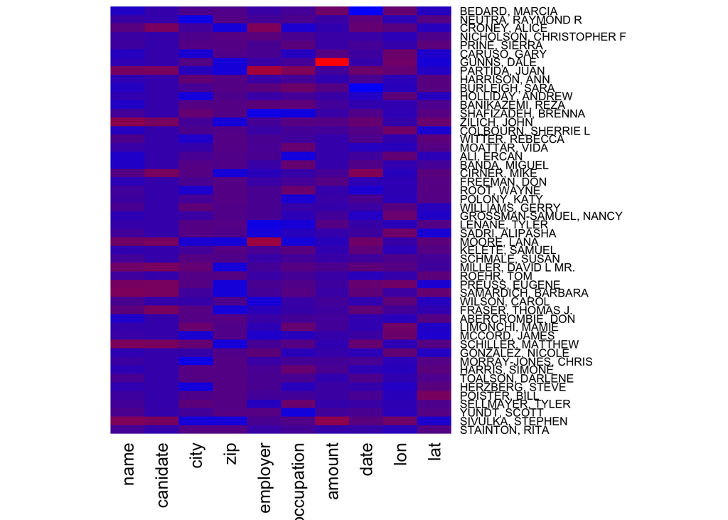